# EI-EP06-respuesta-equipo-8

2025-09-24

## **Contexto**

En el trabajo de título de una estudiante del DIINF se reportan tiempos de ejecución (en milisegundos) y la cercanía con la solución óptima (en por ciento) de la mejor solución encontrada con tres versiones de un algoritmo genético para resolver instancias del problema del vendedor viajero disponibles en repositorios públicos. Ahora debe enfrentar el análisis de estos datos, por que está solicitando ayuda de las y los estudiantes de Estadística Inferencial.

```r
datos<- read.csv("EP07 Datos.csv")
head(datos)
```

```
##   instancia n.nodos n.aristas tiempo.A tiempo.B tiempo.C mejor.A mejor.B
## 1         1      50       631   107534   452595   257485   98.72   98.25
## 2         2      50       521    74808   364061   207297   98.99   99.17
## 3         3      50       588    94072   417798   237793   99.10   99.23
## 4         4      50       653   114830   470701   267598   98.69   99.23
## 5         5      50       597    96720   425233   241770   99.80   99.22
## 6         6      50       564    86688   398448   226833   99.19   99.15
##   mejor.C
## 1   99.34
## 2   99.48
## 3   99.10
## 4   97.82
## 5   98.14
## 6   98.04
```

## **Preguntas**

1. Observando los datos, la memorista sospecha que hay diferencias significativas en el tiempo de ejecución entre las versiones B y C del algoritmo cuando las instancias tienen 75 o más nodos. ¿Los datos respaldan la intuición de la memorista? Para responder, filtren los datos para tener las instancias con 75 o más nodos y seleccionen las columnas de los tiempos de ejecución de las versiones B y C en formato ancho. Usando como semilla el valor 23, obtenga muestras aleatorias independientes de 23 tiempos registrados por la versión B y 20 tiempos registrados por la versión C del algoritmo. Realicen un análisis estadístico pertinente (enunciar hipótesis, revisar condiciones, seleccionar pruebas ómnibus y post-hoc según corresponda) para responder la pregunta planteada, utilizando pruebas no paramétricas de ser necesario.

#### **Respuesta**

Primero filtraremos los datos

```r
tiempo_B <- filter(datos,n.nodos>=75)$tiempo.B
tiempo_C <- filter(datos,n.nodos>=75)$tiempo.C
```

Sabemos que estamos en presencia de 2 muestras, procederemos a checkear la normalidad de los datos mediante la prueba de normalidad de shapiro-wilk

```r
cat("Prueba de normalidad de shapiro-wilk para tiempo B:\n")
```

```
## Prueba de normalidad de shapiro-wilk para tiempo B:
```

```r
print(shapiro.test(tiempo_B))
```

```
##
##  Shapiro-Wilk normality test
##
## data:  tiempo_B
## W = 0.96394, p-value = 0.004514
```

```r
cat("Prueba de normaildad de shapiro-wilk para tiempo C:\n")
```

```
## Prueba de normaildad de shapiro-wilk para tiempo C:
```

```r
print(shapiro.test(tiempo_C))
```

```
##
##  Shapiro-Wilk normality test
##
## data:  tiempo_C
## W = 0.96402, p-value = 0.004578
```

Dado que la pueba de shapiro toma como hipotesis nula que los datos si siguen una distribución normal y los valores p reportados por la prueba para los dos tiempos son 0.004514 y 0.004578 para el tiempo B y C respectivamente podemos decir que los datos no siguen una dsitribución normal por lo que la prueba más acertada será una U Mann-witney test de 2 muestras no parametrica, ya que los datos no siguen normalidad, para realizar esta prueba necesitamos verificar las siguientes condiciones y estas son independientes

1. escala ordinal, esta se puede confirmar ya que lo que se reporta son tiempos de ejecución, estos de por si estan en una escala es decir no es lo mismo un tiempo de ejecución de 1 a un tiempo de ejecución de 1000, se entiende que un tiempo de ejecución menor es mejor que uno mayor
2. Independencia de las muestras, sabemos que estas son independientes ya que cada algoritmo no depende de otro cada uno es independiente

Dicho esto podemos definir nuestras hipotesis

- $H_0$: No existen diferencias significativas en el tiempo de ejecución entre las versiones B y C del algoritmo cuando las instancias tienen 75 o más nodos
- $H_a$: existen diferencias significativas en el tiempo de ejecución entre las versiones B y C del algoritmo cuando las instancias tienen 75 o más nodos

Definidas nuestras hipotesis y verificadas las condiciones de la prueba, procedemos a ejecutarla

```r
cat("Prueba de U Mann-witney:\n")
```

```
## Prueba de U Mann-witney:
```

```r
print(wilcox.test(tiempo_B,tiempo_C,paired=FALSE,alternative = "two.sided", conf.level = 1 - 0.05))
```

```
##
##  Wilcoxon rank sum test with continuity correction
##
## data:  tiempo_B and tiempo_C
## W = 10326, p-value < 2.2e-16
## alternative hypothesis: true location shift is not equal to 0
```

Luego con un nivel de significancia de 0.05 y un valor p reportado por la prueba de 2.2e-16, existe evidencia suficiente para rechazar la hipotesis nula en favor de la hipotesis alternativa, por lo que podemos concluir que si existen diferencias significativas en el tiempo de ejecución entre las versiones B y C del algoritmo cuando las instancias tienen 75 o más nodos.

2. La memorista también sospecha que, al comparar las mismas instancias de iguales características, las mejores soluciones encontradas por las versiones B y C tienen rendimientos distintos. ¿Estará en lo cierto? Para responder, filtren los datos para tener las instancias con 75 o más nodos y seleccionen las columnas con el mejor rendimiento de las versiones B y C en formato ancho. Usando como semilla el valor 73, obtengan una muestra aleatoria de 19 instancias. Realicen un análisis estadístico pertinente (enunciar hipótesis, revisar condiciones, seleccionar pruebas ómnibus y post-hoc según corresponda) para responder la pregunta planteada, utilizando pruebas no paramétricas de ser necesario.

#### **Respuesta**

```r
#seteamos la semilla para los valores aleatorios
set.seed(73)

mejores_tiempos_B <- filter(datos, n.nodos>=75)$mejor.B
mejores_tiempos_C <- filter(datos, n.nodos>=75)$mejor.C

datos_largos <- filter(datos, n.nodos>=75)
datos_largos <- datos_largos[,c(-2,-3,-4,-5,-6,-7)]
head(datos_largos)
```

```
##   instancia mejor.B mejor.C
## 1        61   97.23   97.65
## 2        62   97.16   97.30
## 3        63   96.93   97.35
## 4        64   98.19   97.08
## 5        65   95.33   95.48
## 6        66   98.84   98.42
```

```r
#luego seleccionaremos 19 datos randoms del formato largo

datos_random <- datos_largos[sample(nrow(datos_largos),19),]
datos_random
```

```
##     instancia mejor.B mejor.C
## 61        121   86.85   97.20
## 71        131   94.47   91.74
## 88        148   94.59   92.90
## 17         77   97.50   95.63
## 47        107   94.93   97.12
## 7          67   98.66   97.65
## 19         79   96.09   98.34
## 84        144   91.84   95.81
## 95        155   95.45   89.33
## 31         91   93.91   99.14
## 27         87   95.97   95.91
## 107       167   96.14   98.11
## 54        114   94.46   95.46
## 68        128   90.90   98.63
## 8          68   95.60   98.48
## 5          65   95.33   95.48
## 40        100   97.46   98.62
## 1          61   97.23   97.65
## 93        153   96.78   91.76
```

Revisaremos la normalidad de los datos

```r
cat("Prueba de normalidad de shapiro-wilk para mejor B:\n")
```

```
## Prueba de normalidad de shapiro-wilk para mejor B:
```

```r
print(shapiro.test(datos_largos$mejor.B))
```

```
##
##  Shapiro-Wilk normality test
##
## data:  datos_largos$mejor.B
## W = 0.94582, p-value = 0.000217
```

```r
cat("Prueba de normalidad de shapiro-wilk para mejor c:\n")
```

```
## Prueba de normalidad de shapiro-wilk para mejor c:
```

```r
print(shapiro.test(datos_largos$mejor.C))
```

```
##
##  Shapiro-Wilk normality test
##
## data:  datos_largos$mejor.C
## W = 0.94635, p-value = 0.0002353
```

Teniendo en cuenta que la prueba de shapiro wilk toma como hipotesis nula que los datos siguen una distribución normal, podemos de que que con un 0.05 de nivel de significancia y un p value de 0.000217 y 0.0002353 para el mejor tiempo de b y c respectivamente, los datos **no** siguen un aditribución normal

por lo que estamos en presencia de una prueba con la cual podamos analizar datos que no sigue una ditribución normal y además como son evaluadas de una misma intancias sabemos que estan relacionadas (pareadas), por lo que ocuparemos una prueba de Wilcoxon signed rank test de 2 muestras relacionadas, para esto debemos cumplir con 2 condiciones:

1. Las observaciones son independientes, esto lo podemos verificar ya que si bien es una misma intancia para las 2, son algoritmos diferneteses decir no influye el tiempo del algotimo B en el algortimo C
2. la escala de medion debe ser ordinal, esta se puede confirmar ya que lo que se reporta son tiempos de ejecución, estos de por si estan en una escala es decir no es lo mismo un tiempo de ejecución de 1 a un tiempo de ejecución de 1000, se entiende que un tiempo de ejecución menor es mejor que uno mayor

Ahora enunciaremos nuestras hipotesis para la prueba las cuales son:

- $H_0$: No existe diferencia entre los mejores tiempos de los algoritmos B y C para las mismas intancias
- $H_a$: existe diferencia entre los mejores tiempos de los algoritmos B y C para las mismas intancias

Luego aplicamos la prueba:

```r
prueba <- wilcox.test(datos_largos$mejor.B, datos_largos$mejor.C, paired = TRUE, alternative = "two.sided", conf.level = 1-0.05)
print(prueba)
```

```
##
##  Wilcoxon signed rank test with continuity correction
##
## data:  datos_largos$mejor.B and datos_largos$mejor.C
## V = 1476.5, p-value = 2.619e-06
## alternative hypothesis: true location shift is not equal to 0
```

Luego podemos apreciar que con un intervalo de confianza del 0.05 y un p-value de 2.619e-06 reportado por la prueba, existe evidencia suficiente para recharzar la hipotesis nula por lo que aceptamos la hipoteisis alternativa por lo que podemos decirle a la memorista que en efecto, existe diferencia entre los mejores tiempos de los algoritmos B y C para las mismas intancias.

3. La memorista sospecha que hay diferencias significativas en el tiempo de ejecución entre las versiones del algoritmo cuando las instancias de prueba tienen 50 o más nodos. ¿Los datos respaldan la intuición de la memorista? Para responder, filtren los datos para tener las instancias con 50 o más nodos y seleccionen las columnas con los tiempos de ejecución registrados (en formato ancho). Usando como semilla el valor 43, obtengan muestras aleatorias independientes de 13, 14 y 13 tiempos registrados por las versiones A, B y C, respectivamente. Realicen un análisis estadístico pertinente (enunciar hipótesis, revisar condiciones, seleccionar pruebas ómnibus y post-hoc según corresponda) para responder la pregunta planteada, utilizando pruebas no paramétricas de ser necesario.

Leemos los datos y los filtramos

```r
datos<- read.csv("EP07 Datos.csv")
head(datos)
```

```
##   instancia n.nodos n.aristas tiempo.A tiempo.B tiempo.C mejor.A mejor.B
## 1         1      50       631   107534   452595   257485   98.72   98.25
## 2         2      50       521    74808   364061   207297   98.99   99.17
## 3         3      50       588    94072   417798   237793   99.10   99.23
## 4         4      50       653   114830   470701   267598   98.69   99.23
## 5         5      50       597    96720   425233   241770   99.80   99.22
## 6         6      50       564    86688   398448   226833   99.19   99.15
##   mejor.C
## 1   99.34
## 2   99.48
## 3   99.10
## 4   97.82
## 5   98.14
## 6   98.04
```

```r
datos3 <- datos %>%
  filter(n.nodos >= 50) %>%
  select(instancia, tiempo.A, tiempo.B, tiempo.C)
head(datos3)
```

```
##   instancia tiempo.A tiempo.B tiempo.C
## 1         1   107534   452595   257485
## 2         2    74808   364061   207297
## 3         3    94072   417798   237793
## 4         4   114830   470701   267598
## 5         5    96720   425233   241770
## 6         6    86688   398448   226833
```

```r
set.seed(43)
timesA <- sample(datos3[["tiempo.A"]], 13)
timesB <- sample(datos3[["tiempo.B"]], 14)
timesC <- sample(datos3[["tiempo.C"]], 13)
time <- c(timesA, timesB, timesC)
version <- c(rep("A", length(timesA)), rep("B", length(timesB)), rep("C", length(timesC))) %>% factor()
timeData <- data.frame(time, version)

head(timeData)
```

```
##      time version
## 1  411999       A
## 2  154137       A
## 3 3608636       A
## 4  491683       A
## 5   96720       A
## 6  554792       A
```

Una vez que tenemos los datos procesados, enunciamos las hipótesis del enunciado a contrastar:

- $H_0$: Los tiempos de ejecución de las versiones del algoritmo, para instancias de 50 o más nodos, no presentan diferencias y tienen la misma distribución.
- $H_a$: Existen diferencias significativas en los tiempos de ejecución entre las tres versiones del algoritmo.

Ahora si analizamos la pregunta y las hipótesis, nos damos cuenta de algunas características del problema que nos resultarán claves para elegir la prueba de hipótesis correcta. Lo más notable es que estamos trabajando con más de 2 muestras, las cuáles son independientes por haber sido elegidas aleatoriamente. Además, estamos trabajando con una variable numérica continua de intervalos iguales.

Entonces, la primera opción a sopesar es la prueba ANOVA de una vía para muestras independientes. A continuación vemos sus condiciones.

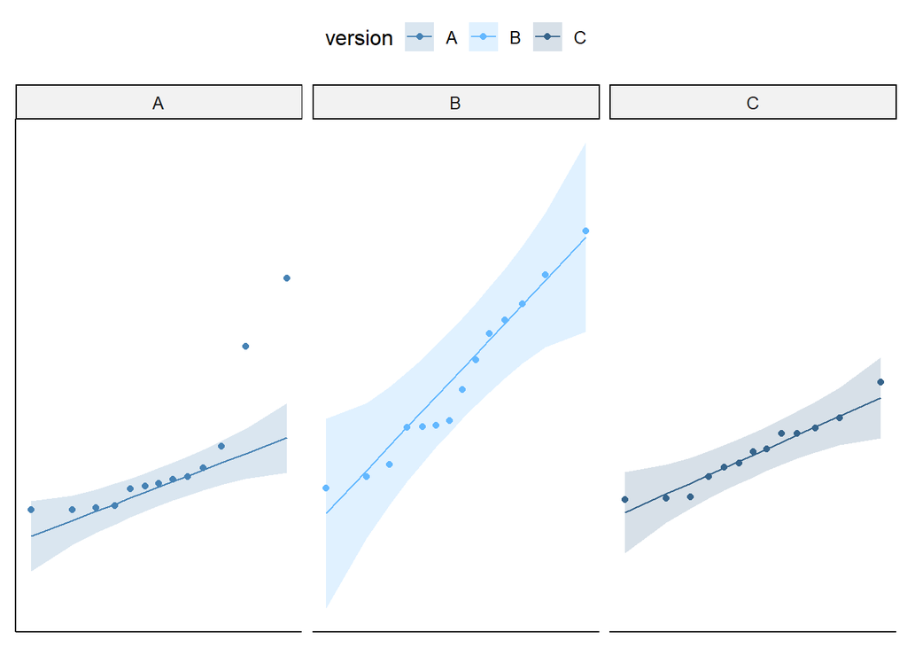

```r
#Comprobar la condición de normalidad con gráfico Q-Q
g1 <- ggqqplot (timeData, x = "time" , y = "version" , color = "version", alpha = 0.5,
                palette = c("steelblue", "steelblue1", "steelblue4"))
g1 <- g1 + facet_wrap(~ version)
g1 <- g1 + rremove ("x.ticks") + rremove ("x.text")
g1 <- g1 + rremove ("y.ticks") + rremove ("y.text")
g1 <- g1 + rremove ("axis.title")
print (g1)
```

Si bien los gráficos de las versiones B y C indican que están dentro del rango aceptable para ser considerados distribuciones normales, la versión A tiene dos valores que claramente se alejan del rango aceptable. Realizamos una prueba de normalidad de Shapiro-Wilk para confirmar.

```r
shapiro.test(timesA)
```

```
##
##  Shapiro-Wilk normality test
##
## data:  timesA
## W = 0.69495, p-value = 0.0004942
```

Si consideramos una significancia de $\alpha = 0.05$, es un error considerar la muestra como normal. Entonces la condición de normalidad no se cumple.

Esta condición ya es razón suficiente para descartar la prueba de ANOVA, pero otra razón que impide usar la prueba mencionada es que los tamaños de las muestras son diferentes, por lo que la prueba ANOVA pierde robustez.

La prueba que ahora nos puede ayudar es su equivalente no paramétrica, la prueba de Kruskal-Wallis. Revisamos sus condiciones.

1. La escala de la variable dependiente debe ser, a lo menos, ordinal: como ya se dijo, el tiempo al ser una magnitud física cumple con la condición.
2. Las observaciones son independientes entre sí: el tiempo de una instancia no debería influir en el tiempo de otra instancia.
3. La variable independiente debe tener a lo menos dos niveles: la variable independiente, la versión del algoritmo, tiene tres niveles.

Como se cumplen todas las condiciones, procedemos a realizar la prueba.

```r
test <- kruskal.test(time ~ version, data = timeData)
print(test)
```

```
##
##  Kruskal-Wallis rank sum test
##
## data:  time by version
## Kruskal-Wallis chi-squared = 12.159, df = 2, p-value = 0.002289
```

La prueba nos retorna el estadístico $H=12.159$ y el valor $p=0.002$, y si volvemos a considerar una significancia de $\alpha = 0.05$, entonces se debe rechazar la hipótesis nula en favor de la alternativa. En otras palabras, existe una diferencia en las distribuciones de tiempos para al menos dos versiones del algoritmo.

La prueba de Kruskal-Wallis al ser una prueba general, solo nos responde que existe una diferencia, pero sin mayor detalle. Para llegar a una conclusión satisfactoria, procedemos a realizar procedimientos post-hoc, con ajuste de Benjamini y Hochberg.

```r
postTest <- pairwise.wilcox.test(timeData[["time"]], timeData[["version"]], p.adjust.method = "BH", paired = FALSE, exact = FALSE)
print(postTest)
```

```
##
##  Pairwise comparisons using Wilcoxon rank sum test with continuity correction
##
## data:  timeData[["time"]] and timeData[["version"]]
##
##   A     B
## B 0.010 -
## C 0.112 0.012
##
## P value adjustment method: BH
```

Finalmente, los pares A-B y B-C tienen valores p menores a la significancia $\alpha = 0.05$, por lo tanto se rechaza la hipótesis nula de que no existe diferencia entre los dos grupos, en favor de la alternativa. Sin embargo, el par A-C tiene un valor p mayor a la significancia, lo que significa que, al contrario de los anteriores pares, no existe una diferencia significativa entre las versiones A y C. Para ver mejor la diferencia, calculamos las medias de cada muestra.

```r
list(A = mean(timesA), B = mean(timesB), C = mean(timesC))
```

```
## $A
## [1] 841332.2
##
## $B
## [1] 2037929
##
## $C
## [1] 943476.6
```

Entonces, con 95% de confianza, la respuesta al problema es que las versiones A y C no presentan diferencias significativas en su tiempo de ejecución para instancias de 50 o más nodos, mientras que la versión B tiene un peor rendimiento (mayor tiempo).

4. La memorista también sospecha que, al comparar las mismas instancias con iguales características, las mejores soluciones encontradas por las diferentes versiones del algoritmo tienen rendimientos distintos. ¿Estará en lo cierto? Para responder, filtren los datos para tener las instancias con 50 o más nodos y seleccionen las columnas con los mejores rendimientos registrados. Usando como semilla el valor 16, obtengan una muestra aleatoria de 21 instancias. Realicen un análisis estadístico pertinente (enunciar hipótesis, revisar condiciones, seleccionar pruebas ómnibus y post-hoc según corresponda) para responder la pregunta planteada, utilizando pruebas no paramétricas de ser necesario.

Filtramos los datos.

```r
datos4 <- datos %>%
  filter(n.nodos >= 50) %>%
  select(instancia, mejor.A, mejor.B, mejor.C)
head(datos4)
```

```
##   instancia mejor.A mejor.B mejor.C
## 1         1   98.72   98.25   99.34
## 2         2   98.99   99.17   99.48
## 3         3   99.10   99.23   99.10
## 4         4   98.69   99.23   97.82
## 5         5   99.80   99.22   98.14
## 6         6   99.19   99.15   98.04
```

```r
set.seed(16)
datos4 <- datos4[sample(nrow(datos4), 21), ]
bestA <- datos4[["mejor.A"]]
bestB <- datos4[["mejor.B"]]
bestC <- datos4[["mejor.C"]]

percentage <- c(bestA, bestB, bestC)
version <- c(rep("A", length(bestA)), rep("B", length(bestB)), rep("C", length(bestC))) %>% factor()
case <- rep(1:21, 3)
percentageData <- data.frame(case, percentage, version)

head(percentageData)
```

```
##   case percentage version
## 1    1      96.66       A
## 2    2      99.05       A
## 3    3      99.51       A
## 4    4      99.79       A
## 5    5      99.55       A
## 6    6      97.59       A
```

Ahora que tenemos los datos, establecemos explícitamente las hipótesis con las que trabajaremos.

- $H_0$: No existe diferencia entre los rendimientos de las versiones del algoritmo para sus mejores soluciones.
- $H_a$: Existe una diferencia significativa entre al menos un par de versiones.

Podemos darnos cuenta que nuevamente estamos trabajando con más de dos muestras. Sin embargo, contrario al problema anterior, las muestras están correlacionadas, dado que cada observación consiste de la misma instancia resuelta por las tres versiones del algoritmo.

Entonces, debemos ver si es posible usar la prueba ANOVA de una vía para muestras correlacionadas.

Revisamos las condiciones para usar la prueba.

1. La escala con que se mide la variable dependiente tiene las propiedades de una escala de intervalos iguales: la variable dependiente es un porcentaje, por lo que podemos entender que la distancia entre un porcentaje a otro es constante e igual para otras posiciones, además el valor cero no representa la falta de un porcentaje.
2. Las mediciones son independientes al interior de cada grupo: las 21 observaciones fueron elegidas al azar, por ende son independientes y no influyeron en la elección de otra.
3. Se puede suponer razonablemente que las poblaciones de origen siguen una distribución normal: para esto usaremos un gráfico Q-Q

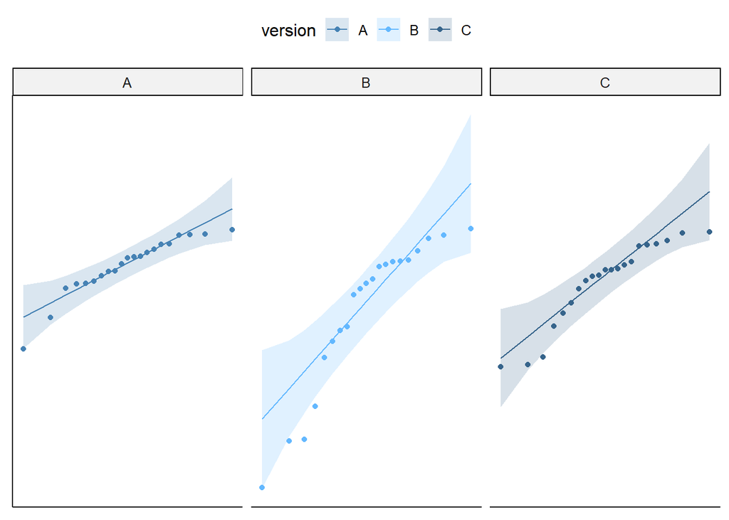

```r
#Comprobar la condición de normalidad con gráfico Q-Q
g1 <- ggqqplot (percentageData, x = "percentage" , y = "version" , color = "version", alpha = 0.5,
                palette = c("steelblue", "steelblue1", "steelblue4"))
g1 <- g1 + facet_wrap(~ version)
g1 <- g1 + rremove ("x.ticks") + rremove ("x.text")
g1 <- g1 + rremove ("y.ticks") + rremove ("y.text")
g1 <- g1 + rremove ("axis.title")
print (g1)
```

Los gráficos nos muestran que las tres versiones contienen observaciones que se alejan de la normalidad, más notablemente la muestra B. No es necesario realizar otra prueba de normalidad, ya que queda claro, por observación, que la versión B no sigue una distribución normal.

Ya que no se puede comprobar la condición de normalidad, nos queda la versión no paramétrica de la prueba, la prueba de Friedman. Revisamos sus condiciones.

1. La escala de la variable dependiente debe ser, a lo menos, ordinal: los porcentajes son una escala de intervalos iguales, ya que tienen orden y un intervalo es constante.
2. Las observaciones son una muestra aleatoria e independiente de la población: las muestras fueron elegidas aleatoriamente, y son independientes de la población de origen.
3. La variable independiente debe ser categórica y tener a lo menos tres niveles: la variable categórica es la versión del algoritmo, y tiene tres niveles.

Una vez que comprobamos que se cumplen todas las condiciones, realizamos la prueba de Friedman.

```r
test <- friedman.test(percentage ~ version | case, data = percentageData)
print(test)
```

```
##
##  Friedman rank sum test
##
## data:  percentage and version and case
## Friedman chi-squared = 10.627, df = 2, p-value = 0.004926
```

Ya que se encontró una diferencia con la prueba ómnibus, es necesario realizar alguna prueba post-hoc para revelar dónde está la diferencia, y llegar a una conclusión más significativa. En este caso se usará el ajuste de Holm.

```r
postTest <- pairwise.wilcox.test(percentageData[["percentage"]], percentageData[["version"]],
                                 p.adjust.method = "holm", paired = TRUE, exact = FALSE)
print(postTest)
```

```
##
##  Pairwise comparisons using Wilcoxon signed rank test with continuity correction
##
## data:  percentageData[["percentage"]] and percentageData[["version"]]
##
##   A    B
## B 0.01 -
## C 0.14 0.14
##
## P value adjustment method: holm
```

Se puede ver que los pares A-C y B-C tienen valores p mayores al nivel de significación previamente elegido $\alpha = 0.05$, lo que implica que se rechaza la hipótesis hipótesis alternativa, es decir, no hay diferencia notable entre los pares de versiones. Sin embargo, el par A-B tiene un valor p menor a la significancia, así que existe una diferencia significativa en los porcentajes para la solución óptima entre la versión A y B del algoritmo. Calculamos las medias de las muestra para las versiones A y B para ver en que sentido está la diferencia.

```r
list(A = mean(bestA), B = mean(bestB), C = mean(bestC))
```

```
## $A
## [1] 97.87333
##
## $B
## [1] 95.41952
##
## $C
## [1] 96.98619
```

Con los resultados de la prueba post-hoc y las medias de los grupos queda claro que el mejor algoritmo es el A, y el peor el B; a eso se debe la diferencia entre A y B, mas no de A con C o B con C. Por lo tanto, con 95% de confianza, se puede concluir que las versiones del algoritmo tienen rendimientos distintos para las mismas instancias del problema, en específico la mejor versión es la A.